# INTRODUCTION TO LINEAR REGRESSION

WEEK 5 NOTES

Author

Tess Vu

Published

October 6, 2025

# Opening Question

**Scenario:** You’re advising a state agency on resource allocation.

Some counties have sparse data. Can you **predict** their median income using data from counties with better measurements?

**Broader question:** How do we make informed predictions when we don’t have complete information?

# Today’s Roadmap

1. **The Statistical Learning Framework:** What are we actually doing?
2. **Two goals:** Understanding relationships vs Making predictions
3. **Building your first model** with PA census data
4. **Model evaluation:** How do we know if it’s any good?
5. **Checking assumptions:** When can we trust the model?
6. **Improving predictions:** Transformations, multiple variables

# Part 1: The Statistical Learning Framework

## The General Problem

We observe data: counties, income, population, education, etc.

We believe there’s some **relationship** between these variables.

**Statistical learning** = a set of approaches for estimating that relationship

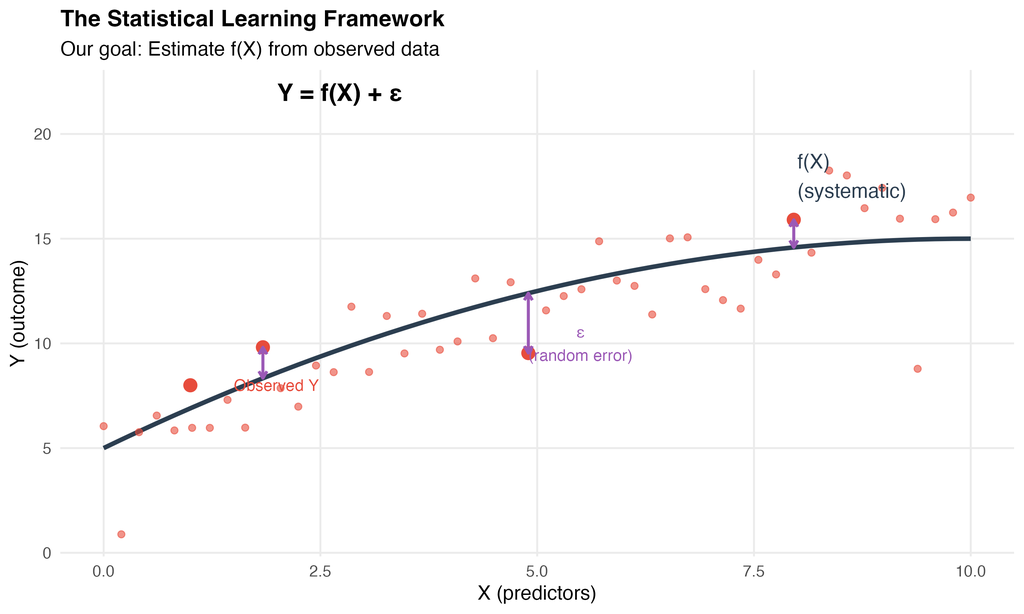

## Formalizing the Relationship

For any quantitative response Y and predictors X₁, X₂, … Xₚ:

$$Y = f(X) + \epsilon$$

Where:

- **f** = the systematic information X provides about Y
- **ε** = random error (irreducible)

## What is f?

**f represents the true relationship** between predictors and outcome

- It’s **fixed** but **unknown**
- It’s what we’re trying to estimate
- Different X values produce different Y values through f

**Example:**

- Y = median income
- X = population, education, poverty rate
- f = the way these factors systematically relate to income

## Why Estimate f?

Two main reasons:

**1. Prediction**

- Estimate Y for new observations
- Don’t necessarily care about the exact form of f
- Focus: accuracy of predictions

**2. Inference**

- Understand how X affects Y
- Which predictors matter?
- What’s the nature of the relationship?
- Focus: interpreting the model

## How Do We Estimate f?

**Two broad approaches:**

**Parametric Methods**

- Make an assumption about the functional form (e.g., linear)
- Reduces problem to estimating a few parameters
- Easier to interpret
- **This is what we’ll focus on**

**Non-Parametric Methods**

- Don’t assume a specific form
- More flexible
- Require more data
- Harder to interpret

## Parametric vs. Non-Parametric

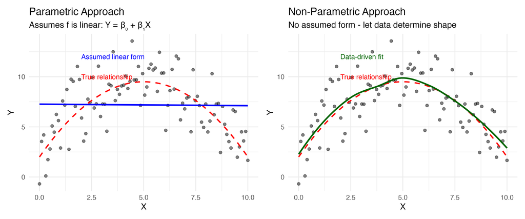

**Key difference:**

- **Parametric (blue):** We assume f is linear, then estimate β₀ and β₁
- **Non-parametric (green):** We let the data determine the shape of f

**NoteWhat about deep learning?**

Neural networks are technically parametric (millions of parameters!), but achieve flexibility through parameter quantity rather than assuming a rigid form. We won’t cover them in this course, but they follow the same Y = f(X) + ε framework.

## Parametric Approach: Linear Regression

**The assumption:** Relationship between X and Y is linear

$$Y \approx \beta_0 + \beta_1X_1 + \beta_2X_2 + ... + \beta_pX_p$$

**The task:** Estimate the β coefficients using our sample data

**The method:** Ordinary Least Squares (OLS)

## Why Linear Regression?

**Advantages:**

- Simple and interpretable
- Well-understood properties
- Works remarkably well for many problems
- Foundation for more complex methods

**Limitations:**

- Assumes linearity (we’ll test this)
- Sensitive to outliers
- Makes several assumptions (we’ll check these)

# Part 2: Two Different Goals

## Prediction vs Inference

The **same model** serves different purposes:

**Inference**

- “Does education affect income?”
- Focus on coefficients
- Statistical significance matters
- Understand mechanisms

**Prediction**

- “What’s County Y’s income?”
- Focus on accuracy
- Prediction intervals matter
- Don’t need to understand why

**Today:** We’ll do both, but emphasize prediction

## Example: Prediction

**Government use case:**

Census misses people in hard-to-count areas. Can we predict:

- Income for areas with poor survey response?
- Population for planning purposes?
- Resource needs based on demographics?

**The model doesn’t explain WHY** these relationships exist, but if predictions are accurate, they’re useful for policy

## Example: Inference

**Research use case:**

Understanding gentrification:

- Which neighborhood characteristics explain income change?
- How much does education matter vs. proximity to downtown?
- Are policy interventions associated with outcomes?

**Here we care about the coefficients** and what they tell us about mechanisms

## Connection to Week 2: Algorithmic Bias

Remember the healthcare algorithm that discriminated?

**The model:** Predicted healthcare needs using costs as proxy

**Technically:** Probably had good R², low prediction error (good “fit”)

**Ethically:** Learned and amplified existing discrimination

**ImportantCritical Point**

A model can be statistically “good” while being ethically terrible for decision-making.

# Part 3: Building Your First Model

## Start with Data and Visualization

Let’s apply these concepts to PA counties:

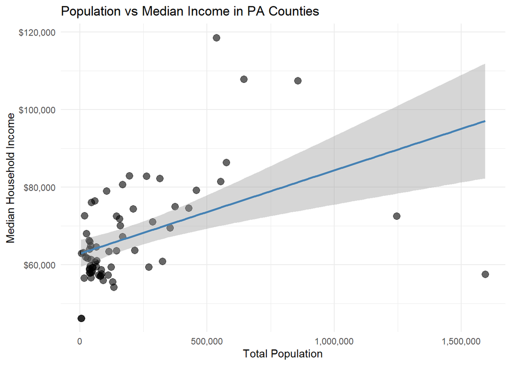

## What Do We See?

**Before fitting any model, discuss the visualization:**

- Generally positive relationship
- Considerable scatter (not deterministic)
- Most counties are small (clustered left)
- One large county with surprisingly low income
- Wider confidence band at higher populations

**Question:** What does this tell us about f(X)?

## Fit the Model

```r
model1 <- lm(median_incomeE ~ total_popE, data = pa_data)
summary(model1)
```

```
Call:
lm(formula = median_incomeE ~ total_popE, data = pa_data)

Residuals:
   Min     1Q Median     3Q    Max
-39536  -6013  -1868   5075  44196

Coefficients:
                Estimate   Std. Error t value             Pr(>|t|)
(Intercept) 62855.819808  1760.477709  35.704 < 0.0000000000000002 ***
total_popE      0.021477     0.005192   4.137             0.000103 ***
---
Signif. codes:  0 '***' 0.001 '**' 0.01 '*' 0.05 '.' 0.1 ' ' 1

Residual standard error: 11820 on 65 degrees of freedom
Multiple R-squared:  0.2084,    Adjusted R-squared:  0.1962
F-statistic: 17.11 on 1 and 65 DF,  p-value: 0.0001032
```

## Interpreting Coefficients

**Intercept (β₀) = $62,855**

- Expected income when population = 0
- Not usually meaningful in practice

**Slope (β₁) = $0.02**

- For each additional person, income increases by $0.02
- **More useful:** For every 1,000 people, income increases by ~$20

**Is this relationship real?**

- p-value < 0.001 → Very unlikely to see this if true β₁ = 0
- We can reject the null hypothesis

## The “Holy Grail” Concept

Our estimates are just that: **estimates** of the true (unknown) parameters

**Key insight:**

- Red line = true relationship (unknowable)
- Blue line = our estimate from this sample
- Different samples → slightly different blue lines
- Standard errors quantify this uncertainty

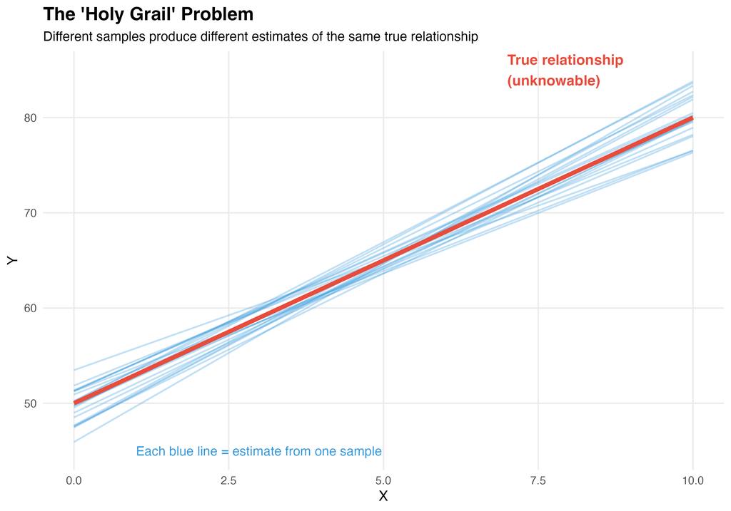

## Statistical Significance

**The logic:**

1. **Null hypothesis (H₀):** β₁ = 0 (no relationship)
2. **Our estimate:** β₁ = 0.02
3. **Question:** Could we get 0.02 just by chance if H₀ is true?

**t-statistic:** How many standard errors away from 0?

- Bigger |t| = more confidence the relationship is real

**p-value:** Probability of seeing our estimate if H₀ is true

- Small p → reject H₀, conclude relationship exists

# Part 4: Model Evaluation

## How Good is This Model?

**Two key questions:**

1. **How well does it fit the data we used?** (in-sample fit)
2. **How well would it predict new data?** (out-of-sample performance)

**These are NOT the same thing!**

## In-Sample Fit: R²

**R² = 0.208**

“21% of variation in income is explained by population”

**Is this good?**

- Depends on your goal!
- For prediction: Moderate
- For inference: Shows population matters, but other factors exist

**R² alone doesn’t tell us if the model is trustworthy**

## The Problem: Overfitting

**Three scenarios:**

1. **Underfitting:** Model too simple (high bias)
2. **Good fit:** Captures pattern without noise
3. **Overfitting:** Memorizes training data (high variance)

## Overfitting in Regression

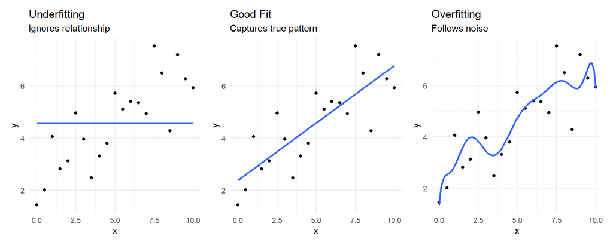

**The danger:** High R² doesn’t mean good predictions!

## Train/Test Split

**Solution:** Hold out some data to test predictions

```r
set.seed(123)
n <- nrow(pa_data)

# 70% training, 30% testing
train_indices <- sample(1:n, size = 0.7 * n)
train_data <- pa_data[train_indices, ]
test_data <- pa_data[-train_indices, ]

# Fit on training data only
model_train <- lm(median_incomeE ~ total_popE, data = train_data)

# Predict on test data
test_predictions <- predict(model_train, newdata = test_data)
```

## Evaluate Predictions

```r
# Calculate prediction error (RMSE)
rmse_test <- sqrt(mean((test_data$median_incomeE - test_predictions)^2))
rmse_train <- summary(model_train)$sigma

cat("Training RMSE:", round(rmse_train, 0), "\n")
```

```
Training RMSE: 12893
```

```r
cat("Test RMSE:", round(rmse_test, 0), "\n")
```

```
Test RMSE: 9536
```

**NoteInterpreting RMSE**

On new data (test set), our predictions are off by ~$9,500 on average. Is this level of error acceptable for policy decisions?

## Cross-Validation

**Better approach:** Multiple train/test splits

[figure not shown]

**Gives more stable estimate of true prediction performance**

## Cross-Validation in Action

```r
library(caret)

# 10-fold cross-validation
train_control <- trainControl(method = "cv", number = 10)

cv_model <- train(median_incomeE ~ total_popE,
                  data = pa_data,
                  method = "lm",
                  trControl = train_control)

cv_model$results
```

```
  intercept     RMSE  Rsquared      MAE   RMSESD RsquaredSD    MAESD
1      TRUE 12577.76 0.5643826 8859.865 5609.002  0.2997098 2238.042
```

**Key Metrics (Averaged Across 10 Folds)**

- **RMSE:** Typical prediction error (~$12,578)
- **R²:** % of variation explained (0.564)
- **MAE:** Average absolute error (~$8,860) - easier to interpret

# Part 5: Checking Assumptions

## When Can We Trust This Model?

Linear regression makes assumptions. If violated:

- Coefficients may be biased
- Standard errors wrong
- Predictions unreliable

**We must check diagnostics** before trusting any model

## Assumption 1: Linearity

**What we assume:** Relationship is actually linear

**How to check:** Residual plot

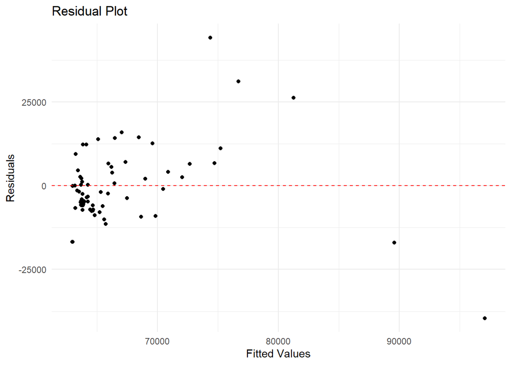

```r
pa_data$residuals <- residuals(model1)
pa_data$fitted <- fitted(model1)

ggplot(pa_data, aes(x = fitted, y = residuals)) +
  geom_point() +
  geom_hline(yintercept = 0, color = "red", linetype = "dashed") +
  labs(title = "Residual Plot", x = "Fitted Values", y = "Residuals") +
  theme_minimal()
```

## Reading Residual Plots

**Good**

- Random scatter
- Points around 0
- Constant spread

**Bad**

- Curved pattern
- Model missing something
- Predictions biased

**ImportantWhy This Matters for Prediction**

**Linearity violations hurt predictions, not just inference:**

- If the true relationship is curved and you fit a straight line, you’ll systematically underpredict in some regions and overpredict in others
- **Biased predictions** in predictable ways (not random errors!)
- Residual plots should show **random scatter** - any pattern means your model is missing something systematic

## Assumption 2: Constant Variance

**Heteroscedasticity:** Variance changes across X

**Impact:** Standard errors are wrong → p-values misleading

**WarningWhat Heteroskedasticity Tells You**

**Often a symptom of model misspecification:**

- Model fits well for some values (e.g., small counties) but poorly for others (large counties)
- May indicate **missing variables** that matter more at certain X values
- Ask: “What’s different about observations with large residuals?”

**Example:** Population alone predicts income well in rural counties, but large urban counties need additional variables (education, industry) to predict accurately.

## Heteroskedasticity Visualized

[figure not shown]

**Key Insight:** Adding the right predictor can fix heteroscedasticity

## Formal Test: Breusch-Pagan

```r
library(lmtest)
bptest(model1)
```

```
    studentized Breusch-Pagan test

data:  model1
BP = 27.481, df = 1, p-value = 0.0000001587
```

**Interpretation:**

- **p > 0.05:** Constant variance assumption OK
- **p < 0.05:** Evidence of heteroscedasticity

**If detected, solutions:**

1. Transform Y (try `log(income)`)
2. Robust standard errors
3. Add missing variables
4. Accept it (point predictions still OK for prediction goals)

## Assumption: Normality of Residuals

**What we assume:** Residuals are normally distributed

**Why it matters:**

- Less critical for **point predictions** (unbiased regardless)
- Important for **confidence intervals** and **prediction intervals**
- Needed for valid hypothesis tests (t-tests, F-tests)

# Q-Q Plot

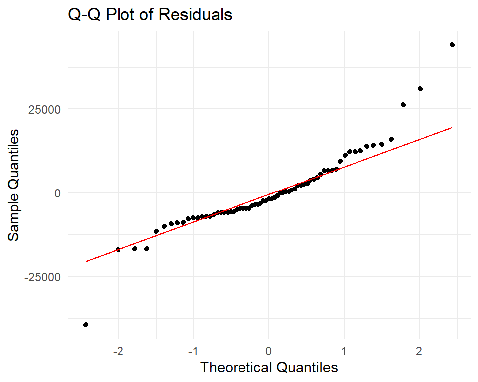

## Assumption 3: No Multicollinearity

**For multiple regression:** Predictors shouldn’t be too correlated

```r
library(car)
vif(model1)  # Variance Inflation Factor

# Rule of thumb: VIF > 10 suggests problems
# Not relevant with only 1 predictor!
```

**Why it matters:** Coefficients become unstable, hard to interpret

## Assumption 4: No Influential Outliers

**Not all outliers are problems** - only those with high leverage AND large residuals

### Visual Diagnostic

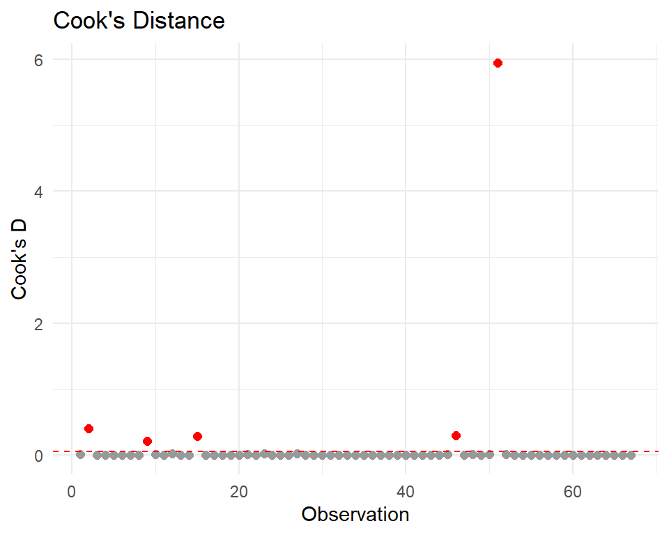

### Identify Influential Points

```
# A tibble: 2 × 4
  NAME                              total_popE median_incomeE cooks_d
  <chr>                                  <dbl>          <dbl>   <dbl>
1 Philadelphia County, Pennsylvania    1593208          57537   5.95
2 Allegheny County, Pennsylvania       1245310          72537   0.399
```

**Interpretation:**

- Cook’s D > 4/n = potentially influential
- High leverage + large residual = pulls regression line

## What To Do With Influential Points

**TipInvestigation Strategy**

1. **Investigate:** Why is this observation unusual? (data error? truly unique?)
2. **Report:** Always note influential observations in your analysis
3. **Sensitivity check:** Refit model without them - do conclusions change?
4. **Don’t automatically remove:** They might represent real, important cases

**For policy:** An influential county might need **special attention**, not exclusion!

**ImportantConnection to Algorithmic Bias**

High-influence observations in demographic could represent **marginalized communities** or unique populations. Automatically removing them can erase important populations from analysis and lead to biased policy decisions.

**Always investigate before removing!**

# Part 6: Improving the Model

## Adding More Predictors

Maybe population alone isn’t enough:

```
Call:
lm(formula = median_incomeE ~ total_popE + percent_collegeE +
    poverty_rateE, data = pa_data_full)

Residuals:
   Min     1Q Median     3Q    Max
-32939  -4473  -1098   3861  27672

Coefficients:
                    Estimate  Std. Error t value             Pr(>|t|)
(Intercept)      60893.86796  1589.24122  38.316 < 0.0000000000000002 ***
total_popE           0.06657     0.03356   1.984               0.0517 .
percent_collegeE     0.04710     0.14916   0.316               0.7532
poverty_rateE       -0.36503     0.07749  -4.711             0.000014 ***
---
Signif. codes:  0 '***' 0.001 '**' 0.01 '*' 0.05 '.' 0.1 ' ' 1

Residual standard error: 8610 on 63 degrees of freedom
Multiple R-squared:  0.5931,    Adjusted R-squared:  0.5738
F-statistic: 30.61 on 3 and 63 DF,  p-value: 0.000000000002485
```

## Log Transformations

If relationship is curved, try transforming:

```r
# Compare linear vs log
model_linear <- lm(median_incomeE ~ total_popE, data = pa_data)
model_log <- lm(median_incomeE ~ log(total_popE), data = pa_data)

summary(model_log)
```

```
Call:
lm(formula = median_incomeE ~ log(total_popE), data = pa_data)

Residuals:
   Min     1Q Median     3Q    Max
-27231  -5780  -2118   3953  40638

Coefficients:
                Estimate Std. Error t value   Pr(>|t|)
(Intercept)        -4867      12374  -0.393      0.695
log(total_popE)     6276       1074   5.842 0.00000018 ***
---
Signif. codes:  0 '***' 0.001 '**' 0.01 '*' 0.05 '.' 0.1 ' ' 1

Residual standard error: 10760 on 65 degrees of freedom
Multiple R-squared:  0.3443,    Adjusted R-squared:  0.3342
F-statistic: 34.13 on 1 and 65 DF,  p-value: 0.0000001805
```

```r
# Check which residual plot looks better
```

**Interpretation changes:** Log models show percentage relationships

## Categorical Variables

```r
# Create metro/non-metro indicator
pa_data <- pa_data %>%
  mutate(metro = ifelse(total_popE > 500000, 1, 0))

model3 <- lm(median_incomeE ~ total_popE + metro, data = pa_data)
summary(model3)
```

```
Call:
lm(formula = median_incomeE ~ total_popE + metro, data = pa_data)

Residuals:
   Min     1Q Median     3Q    Max
-28825  -6732  -2885   7672  26622

Coefficients:
                Estimate   Std. Error t value             Pr(>|t|)
(Intercept) 64924.857892  1659.821786  39.116 < 0.0000000000000002 ***
total_popE     -0.005290     0.008047  -0.657             0.513257
metro       29865.529225  7319.309190   4.080             0.000127 ***
---
Signif. codes:  0 '***' 0.001 '**' 0.01 '*' 0.05 '.' 0.1 ' ' 1

Residual standard error: 10610 on 64 degrees of freedom
Multiple R-squared:  0.3718,    Adjusted R-squared:  0.3522
F-statistic: 18.94 on 2 and 64 DF,  p-value: 0.0000003456
```

**R creates dummy variables automatically**

# Summary: The Regression Workflow

1. **Understand the framework:** What’s f? What’s the goal?
2. **Visualize first:** Does a linear model make sense?
3. **Fit the model:** Estimate coefficients
4. **Evaluate performance:** Train/test split, cross-validation
5. **Check assumptions:** Residual plots, VIF, outliers
6. **Improve if needed:** Transformations, more variables
7. **Consider ethics:** Who could be harmed by this model?

# Key Takeaways

**Statistical Learning:**

- We’re estimating f(X), the systematic relationship
- Parametric methods assume a form (we chose linear)

**Two purposes:**

- Inference: understand relationships
- Prediction: forecast new values

**Model evaluation:**

- In-sample fit ≠ out-of-sample performance
- Beware overfitting!

**Diagnostics matter:**

- Always check assumptions
- Plots reveal what R² hides

# 🏆 Learning- Focused In-Class Challenge:

*Best Predictive Model Competition*

## The Task

**Predict median home value** (`B25077_001`) for PA counties using any combination of predictors

Build the model with **lowest 10-fold cross-validated RMSE**

## Available Predictors

```r
challenge_data <- get_acs(
  geography = "county",
  state = "PA",
  variables = c(
    home_value = "B25077_001",      # YOUR TARGET
    total_pop = "B01003_001",       # Total population*
    median_income = "B19013_001",   # Median household income
    median_age = "B01002_001",      # Median age*
    percent_college = "B15003_022", # Bachelor's degree or higher*
    median_rent = "B25058_001",     # Median rent
    poverty_rate = "B17001_002"     # Population in poverty*
  ),
  year = 2022,
  output = "wide"
)

challenge_data
```

```r
#hist(challenge_data$total_popE)
#hist(challenge_data$median_ageE)
#hist(challenge_data$percent_collegeE)
#hist(challenge_data$poverty_rateE)

#hist(log(challenge_data$total_popE))
#hist(log(challenge_data$median_ageE))
#hist(log(challenge_data$percent_collegeE))
#hist(log(challenge_data$poverty_rateE))
```

```r
# Set random seed for reproducibility
#set.seed(123)

# Split into 70% training and 30% testing
#n <- nrow(challenge_data)
#train_indices <- sample(1:n, size = 0.7 * n)
#train_data <- challenge_data[train_indices, ]
#test_data  <- challenge_data[-train_indices, ]

# Fit the regression model on training data
#model_train <- lm(
#  home_valueE ~ log(total_popE) + median_ageE + log(percent_collegeE) + log(poverty_rateE),
#  data = train_data
#)

# Predict on both training and test data
#train_predictions <- predict(model_train, newdata = train_data)
test_predictions  <- predict(model_train, newdata = test_data)

# Compute RMSE for training and testing
#rmse_train <- sqrt(mean((train_data$home_valueE - train_predictions)^2))
#rmse_test  <- sqrt(mean((test_data$home_valueE - test_predictions)^2))

# Display results
#cat("Training RMSE:", round(rmse_train, 2), "\n")
#cat("Test RMSE:", round(rmse_test, 2), "\n")

# Show summary of model fit
#summary(model_train)
```

## Rules & Strategy

**You can:**

- Use any combination of predictors (time permitting, you can fetch more)
- Try log transformations: `log(total_popE)`
- Engineer new categorical features
- Remove influential outliers (but document which!)

**You must:**

- Use 10-fold cross-validation to report final RMSE
- Do a full diagnostic check (residual plot, Cook’s D, or Breusch-Pagan)
- Be ready to explain your model in 2 minutes

**TipHints**

- Start simple (one predictor), check diagnostics
- Income and rent are probably highly correlated (multicollinearity!)
- Try log transformation if relationship looks curved
- Don’t forget to remove NAs: `na.omit(challenge_data)`